# Health Care - Insurance Charges by groups

Rafael Veiga

2023-08-12

## Introduction

Hello! In this project, we’re going to take a look at some information about people who buy insurance. Insurance is like a safety net. People pay a little bit of money regularly so that if something big and unexpected happens, the insurance helps cover the costs. We want to find out how things like age, how healthy you are, and if you smoke, can change the amount of money you pay for insurance. By looking at this information, we can learn more about how insurance companies decide on these prices.

## Data Loading and Cleaning

```r
# Installing and Loading the required libraries
install.packages("dplyr")
install.packages("skimr")
install.packages("tidyverse")
```

```r
install.packages("ggplot2")
library(dplyr)
library(skimr)
library(tidyverse)
library(ggplot2)

# Load the dataset
insurance <- read.csv("insurance.csv")

# Encoding categorical variables
insurance$sex <- as.factor(insurance$sex)
insurance$smoker <- as.factor(insurance$smoker)
insurance$region <- as.factor(insurance$region)

# Checking for missing values
missing_values <- sapply(insurance, function(x) sum(is.na(x)))
missing_values
```

```
##      age      sex      bmi children   smoker   region  charges
##        0        0        0        0        0        0        0
```

# Exploratory Data Analysis (EDA)

## Descriptive Statistics

```r
# Summary statistics
summary(insurance)
```

```
##       age            sex           bmi           children     smoker
##  Min.   :18.00   female:662   Min.   :15.96   Min.   :0.000   no :1064
##  1st Qu.:27.00   male  :676   1st Qu.:26.30   1st Qu.:0.000   yes: 274
##  Median :39.00                Median :30.40   Median :1.000
##  Mean   :39.21                Mean   :30.66   Mean   :1.095
##  3rd Qu.:51.00                3rd Qu.:34.69   3rd Qu.:2.000
##  Max.   :64.00                Max.   :53.13   Max.   :5.000
##        region       charges
##  northeast:324   Min.   : 1122
##  northwest:325   1st Qu.: 4740
##  southeast:364   Median : 9382
##  southwest:325   Mean   :13270
##                  3rd Qu.:16640
##                  Max.   :63770
```

## Distribution of Key Variables

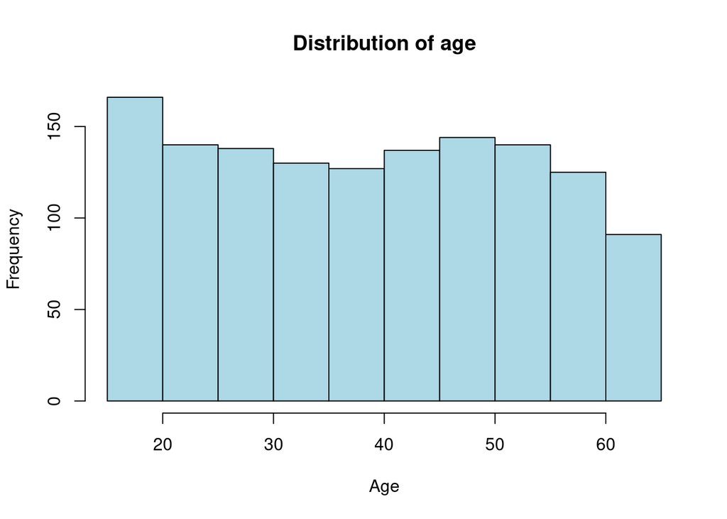

```r
# Histograms for age, BMI, and charges
hist(insurance$age, main = "Distribution of age", xlab = "Age", col = "lightblue")
```

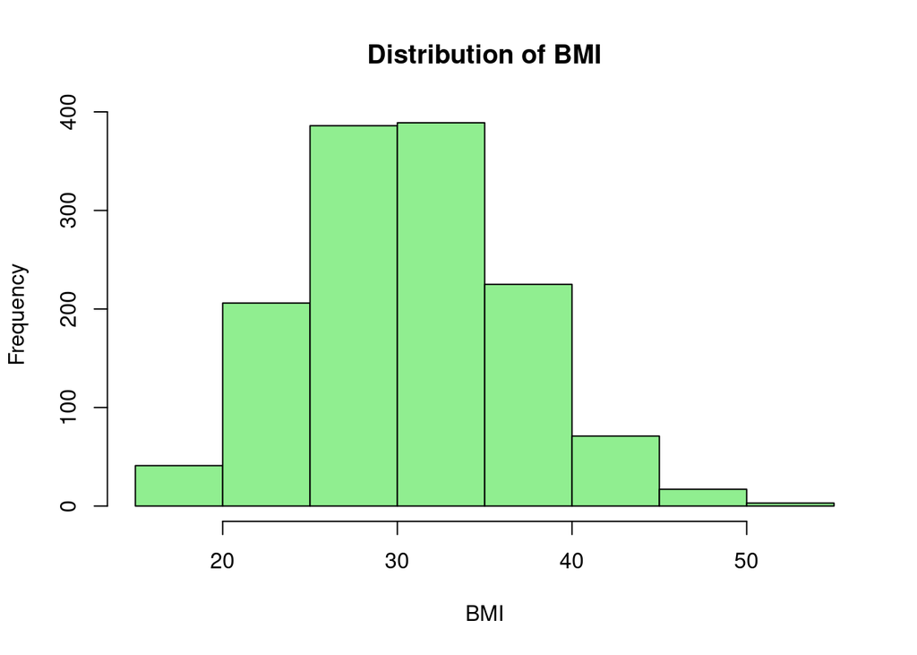

```r
hist(insurance$bmi, main="Distribution of BMI", xlab="BMI", col="lightgreen")
```

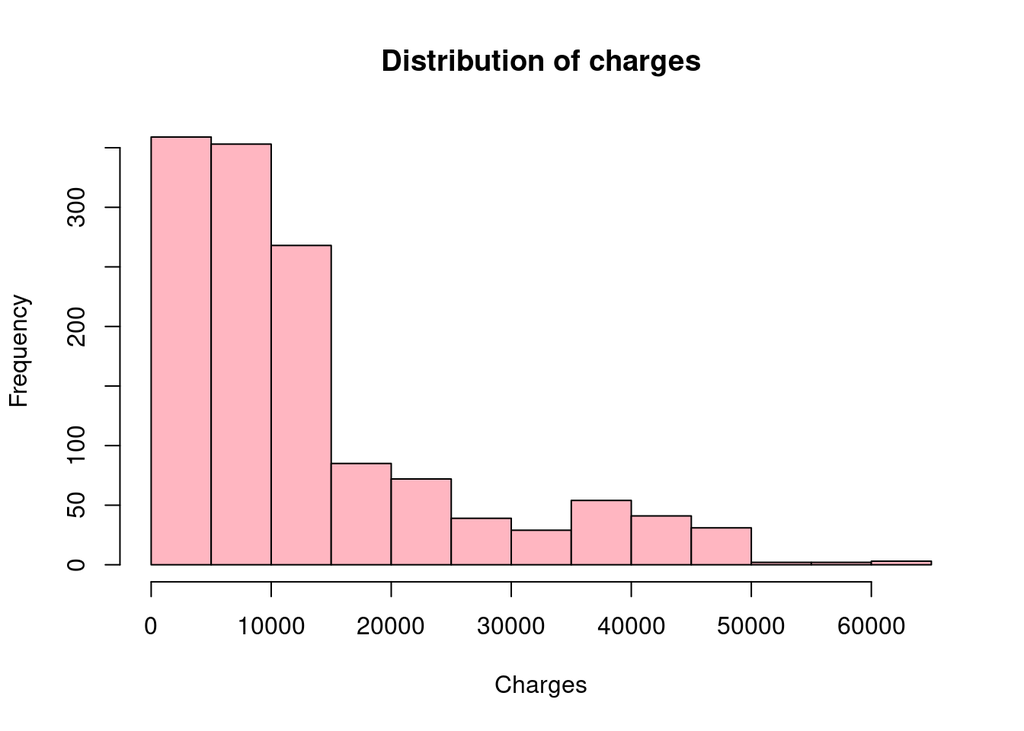

```r
hist(insurance$charges, main="Distribution of charges", xlab="Charges", col="lightpink")
```

# Exploratory Analysis of Insurance Data

## Introduction

I wanted to learn more about our insurance customers. So, I looked at three things: how old they are, their body health score (called BMI), and how much they pay for insurance.

# Age Distribution

## Histogram Analysis:

The age distribution is fairly uniform, with the majority of customers falling between ages 20 to 60. This indicates that the dataset encompasses a broad age range, from young adults to older individuals.

## Key Observations:

# Body Mass Index (BMI) Distribution

## Histogram Analysis:

The BMI histogram showcases that a majority of the insured individuals have a BMI ranging from 25 to 35. This range typically classifies individuals as “Obese” or “Overweight”, indicating a potential health concern for a significant portion of our dataset.

## Key Observations:

A spike in the frequency around the 30 mark suggests that many individuals are on the threshold between “Obese” and “Overweight”, indicating potential health risks. Fewer individuals lie in the “Underweight” and “Normal” BMI categories, pointing towards an increasing trend in overweight issues among the insured.

# Insurance Charges Distribution

## Histogram Analysis:

The distribution of insurance charges is right-skewed, indicating that a majority of the insured individuals have lower charges. However, there’s a noticeable tail, suggesting that a minority of individuals have significantly higher charges.

## Key Observations:

The bulk of customers pay a relatively low insurance charge, which might correspond to basic insurance plans or group benefits. The tail end with higher charges could represent individuals with pre-existing health conditions, higher risk profiles, or premium insurance plans.

# Insurance Charges Analysis by Age, BMI, and Smoking Status

## Objective:

To understand the intricate relationships between age, BMI, smoking habits, and insurance charges. This deep-dive aims to identify specific trends and correlations that could inform both consumers and insurance providers about the determinants of insurance charges.

## Methods:

The dataset was segmented into five age groups. Within each age group, charges were further divided based on four BMI categories: Underweight, Normal, Overweight, and Obese. Each of these segments has two distinct data points: charges for smokers and charges for non-smokers. The results were visualized in a grouped bar chart.

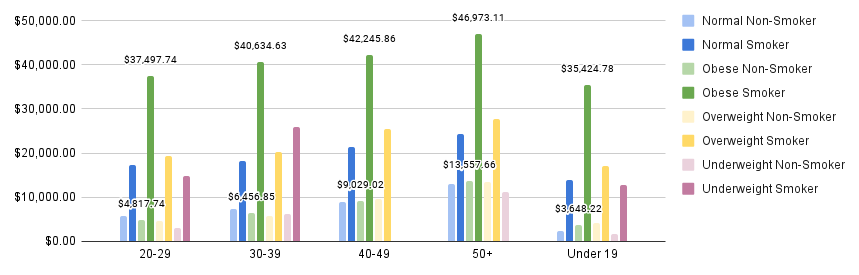

Bar chart with average charges by Age and BMI Groups, separated by Non-Smokers and Smokers

## Findings:

Age Trend: Across all BMI categories, older age groups tend to have higher insurance charges. This is consistent with the understanding that aging is accompanied by increased health risks, making older individuals more costly to insure.

The Dominance of Smoking: Regardless of age or BMI, smokers invariably face steeper insurance charges than their non-smoking counterparts. This gap in charges is particularly pronounced among individuals with higher BMIs, signaling the multiplicative health risks posed by smoking and being overweight.

# Conclusion:

Upon analyzing the dataset related to insurance charges, I identified a distinct pattern linking Body Mass Index (BMI) to insurance costs. Specifically, individuals categorized as ‘obese’ by BMI standards tend to incur higher insurance charges than those in other BMI classifications.

# Recommendations:

Health Initiatives: Introducing health initiatives that focus on individuals in the ‘obese’ BMI bracket can be beneficial. This approach can enhance health outcomes for policyholders and potentially reduce claims in the long run.

Insurance Premium Structuring: It might be constructive to weigh BMI more heavily when determining insurance premiums, ensuring that rates are commensurate with health indicators.

Educational Campaigns: By emphasizing the significance of a balanced BMI and its impact on insurance costs, we can guide individuals towards healthier living choices.

Engagement with Health Experts: Forming alliances with health professionals to facilitate regular health assessments or provide fitness programs at concessional rates can be considered. This strategy can be particularly effective for those in the ‘obese’ BMI range, emphasizing preventive care.

Incentive-Based Pricing: A pricing structure that offers financial incentives or reduced premiums for those who maintain or achieve a balanced BMI could encourage a healthier lifestyle among policyholders.

# Predictive Modeling

## Why Use a Predictive Model?

Imagine you have a magic crystal ball. When you ask it a question about the future, it gives you an answer. That’s kind of what a predictive model does! A predictive model looks at information we already know and uses it to make smart guesses about things we want to find out. In this project, I’m using a predictive model to guess how much money someone might pay for insurance in the future. This helps insurance companies plan better, and it can also help people understand what to expect when they buy insurance.

```r
# Loading required libraries for modeling
install.packages("caTools")
install.packages("randomForest")
library(caTools)
library(randomForest)
# Splitting the dataset
set.seed(123)  # Setting seed for reproducibility
split <- sample.split(insurance$charges, SplitRatio = 0.7)
training_set <- subset(insurance, split == TRUE)
test_set <- subset(insurance, split == FALSE)

# Training the model
set.seed(123)  # Setting seed for reproducibility
model <- randomForest(charges ~ ., data = training_set)
model
```

```
##
## Call:
##  randomForest(formula = charges ~ ., data = training_set)
##                Type of random forest: regression
##                      Number of trees: 500
## No. of variables tried at each split: 2
##
##           Mean of squared residuals: 24833377
##                     % Var explained: 84.56
```

# Conclusion and Further Steps

Project Conclusion:

In this analysis, an insurance dataset was thoroughly examined to understand the factors impacting insurance costs. The initial phase focused on examining the relationships between age, BMI, and insurance charges. It was observed that BMI, particularly in the ‘obese’ range, had a significant relationship with insurance premiums. Age and smoking habits were also important factors.

Using this information, a predictive model was crafted to estimate potential insurance charges based on specific inputs. This model serves as a practical tool that could help professionals provide quick estimates to potential customers, enhancing the efficiency of the consultation process.

## Recommendations for Future Work:

Expand the Dataset: Including more variables like health history or daily activities might improve the model’s predictions.

Regularly Update the Model: As more data becomes available, updating the model will ensure its continued accuracy.

Enhance the User Experience: If the predictive tool is to be used widely, it should be user-friendly and intuitive.

Broader Health Insights: The model could also suggest health tips based on the user’s data.

To wrap up, this project demonstrated the potential of data analysis combined with predictive modeling. Through careful exploration and practical application, the value of data in making informed decisions was showcased.